# Chapter 7 - exercise 1: Titanic

## Cho dữ liệu titanic trong tập tin titanic_csv.csv

### Yêu cầu: Hãy đọc dữ liệu từ tập tin này, áp dụng Random Forest để thực hiện việc xác định người trên tàu Titanic còn sống hay không dựa trên các thông tin được cung cấp.

##### Chi tiết:

1. Đọc dữ liệu. Chuẩn hóa dữ liệu. Từ dữ liệu tạo X gồm các thuộc tính 'pclass', 'sex', 'age', 'sibsp', 'parch', 'fare', 'embarked', y là 'survived'
2. Tạo X_train, X_test, y_train, y_test từ dữ liệu chuẩn hóa với tỷ lệ dữ liệu test là 0.3
3. Áp dụng Random Forest, Tìm kết quả
4. Kiểm tra độ chính xác
5. Tìm các thuộc tính quan trọng nhất trong tập dữ liệu
6. Trực quan hóa thuộc tính quan trọng
7. Áp dụng lại Random Forest dựa trên các thuộc tính quan trọng, tìm kết quả
8. Kiểm tra độ chính xác
9. Tự cho 1 dữ liệu X_test mới. Ví dụ như: X_test =[[tuoi = 35, gia ve =50, gioi tinh = Male, tang lop = 3], [tuoi = 18, gia ve = 250, gioi tinh = Female, tang lop = 2] ] , tìm kết quả Y test.

```python
import numpy as np
import pandas as pd
import matplotlib.pyplot as plt
from sklearn.model_selection import train_test_split
import math
```

```python
data = pd.read_csv("titanic_csv.csv", index_col=0)
```

```python
type(data)
```

```
pandas.core.frame.DataFrame
```

```python
data.info()
```

```
<class 'pandas.core.frame.DataFrame'>
Int64Index: 1309 entries, 1 to 1309
Data columns (total 12 columns):
pclass       1309 non-null int64
survived     1309 non-null int64
name         1309 non-null object
sex          1309 non-null object
age          1046 non-null float64
sibsp        1309 non-null int64
parch        1309 non-null int64
ticket       1309 non-null object
fare         1308 non-null float64
cabin        295 non-null object
embarked     1307 non-null object
home.dest    745 non-null object
dtypes: float64(2), int64(4), object(6)
memory usage: 132.9+ KB
```

```python
data.head()
```

|  | pclass | survived | name | sex | age | sibsp | parch | ticket | fare | cabin | embarked | home.dest |
| --- | --- | --- | --- | --- | --- | --- | --- | --- | --- | --- | --- | --- |
| 1 | 1 | 1 | Allen, Miss. Elisabeth Walton | female | 29.0000 | 0 | 0 | 24160 | 211.3375 | B5 | S | St Louis, MO |
| 2 | 1 | 1 | Allison, Master. Hudson Trevor | male | 0.9167 | 1 | 2 | 113781 | 151.5500 | C22 C26 | S | Montreal, PQ / Chesterville, ON |
| 3 | 1 | 0 | Allison, Miss. Helen Loraine | female | 2.0000 | 1 | 2 | 113781 | 151.5500 | C22 C26 | S | Montreal, PQ / Chesterville, ON |
| 4 | 1 | 0 | Allison, Mr. Hudson Joshua Creighton | male | 30.0000 | 1 | 2 | 113781 | 151.5500 | C22 C26 | S | Montreal, PQ / Chesterville, ON |
| 5 | 1 | 0 | Allison, Mrs. Hudson J C (Bessie Waldo Daniels) | female | 25.0000 | 1 | 2 | 113781 | 151.5500 | C22 C26 | S | Montreal, PQ / Chesterville, ON |

```python
data = data.interpolate()
```

```python
X=data[['pclass', 'sex', 'age', 'sibsp', 'parch', 'fare', 'embarked']]  # Features
y=data['survived']  # Labels
```

```python
X = pd.get_dummies(X)
X.head()
```

|  | pclass | age | sibsp | parch | fare | sex_female | sex_male | embarked_C | embarked_Q | embarked_S |
| --- | --- | --- | --- | --- | --- | --- | --- | --- | --- | --- |
| 1 | 1 | 29.0000 | 0 | 0 | 211.3375 | 1 | 0 | 0 | 0 | 1 |
| 2 | 1 | 0.9167 | 1 | 2 | 151.5500 | 0 | 1 | 0 | 0 | 1 |
| 3 | 1 | 2.0000 | 1 | 2 | 151.5500 | 1 | 0 | 0 | 0 | 1 |
| 4 | 1 | 30.0000 | 1 | 2 | 151.5500 | 0 | 1 | 0 | 0 | 1 |
| 5 | 1 | 25.0000 | 1 | 2 | 151.5500 | 1 | 0 | 0 | 0 | 1 |

```python
from sklearn.model_selection import train_test_split
X_train, X_test, y_train, y_test = train_test_split(X, y, test_size=0.3)
```

```python
from sklearn.ensemble import RandomForestClassifier
clf=RandomForestClassifier(n_estimators=100)
```

```python
clf.fit(X_train,y_train)
y_pred = clf.predict(X_test)
```

```python
from sklearn import metrics
print("Accuracy:",metrics.accuracy_score(y_test, y_pred))
```

```
Accuracy: 0.8091603053435115
```

```python
# Kiểm tra độ chính xác
print("The Training prediction accuracy is: ",
      clf.score(X_train,y_train)*100,"%")
print("The Testing prediction accuracy is: ",
      clf.score(X_test,y_test)*100,"%")
```

```
The Training prediction accuracy is:  98.36244541484717 %
The Testing prediction accuracy is:  80.91603053435115 %
```

```python
# Finding Important Features in Scikit-learn
import pandas as pd
feature_imp = pd.Series(clf.feature_importances_, index = np.array(X.columns)).sort_values(ascending=False)
feature_imp
```

```
age           0.281554
fare          0.242753
sex_male      0.150740
sex_female    0.135277
pclass        0.073153
sibsp         0.039508
parch         0.038026
embarked_C    0.017863
embarked_S    0.015512
embarked_Q    0.005614
dtype: float64
```

```python
type(feature_imp)
```

```
pandas.core.series.Series
```

```python
feature_imp[feature_imp>=0.05].sum()
```

```
0.8834768030877038
```

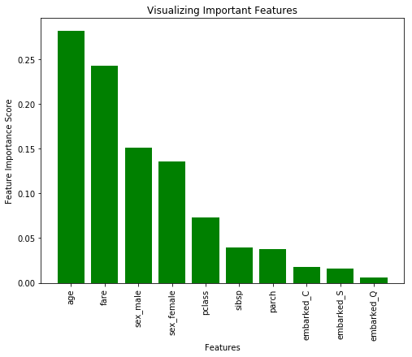

```python
import matplotlib.pyplot as plt
%matplotlib inline
# Creating a bar plot
plt.figure(figsize=(8,6))
plt.bar(feature_imp.index, feature_imp, color="g")
# Add labels to your graph
plt.xlabel('Features')
plt.ylabel('Feature Importance Score')
plt.title("Visualizing Important Features")
plt.xticks(feature_imp.index, rotation='vertical')
plt.show()
```

```python
# Tạo lại dữ liệu huấn luyện và test sau khi bỏ đi các thuộc tính ít quan trọng hơn
X_now = X[['age', 'fare', 'sex_female', 'sex_male', 'pclass']]
y_now = data['survived']
```

```python
# Split dataset into training set and test set
X_train, X_test, y_train, y_test = train_test_split(X_now, y_now, test_size=0.3)
```

```python
clf_now=RandomForestClassifier(n_estimators=100)
clf_now.fit(X_train,y_train)
y_pred=clf_now.predict(X_test)
```

```python
# Model Accuracy, how often is the classifier correct?
# => giảm đôi chút nhưng bỏ được các cột không liên quan
print("Accuracy:",metrics.accuracy_score(y_test, y_pred))
```

```
Accuracy: 0.7888040712468194
```

```python
# Kiểm tra độ chính xác
print("The Training prediction accuracy is: ",
      clf_now.score(X_train,y_train)*100,"%")
print("The Testing prediction accuracy is: ",
      clf_now.score(X_test,y_test)*100,"%")
```

```
The Training prediction accuracy is:  98.7991266375546 %
The Testing prediction accuracy is:  78.88040712468194 %
```

```python
from sklearn.metrics import confusion_matrix
```

```python
confusion_matrix(y_test, y_pred, labels=[0, 1])
```

```
array([[214,  36],
       [ 47,  96]], dtype=int64)
```

```python
# Đánh giá model
from sklearn. metrics import classification_report, roc_auc_score, roc_curve
print(classification_report(y_test, y_pred))
```

```
              precision    recall  f1-score   support

           0       0.82      0.86      0.84       250
           1       0.73      0.67      0.70       143

   micro avg       0.79      0.79      0.79       393
   macro avg       0.77      0.76      0.77       393
weighted avg       0.79      0.79      0.79       393
```

```python
y_prob = clf_now.predict_proba(X_test)
y_probs = y_prob[:, 1]
#y_probs
```

```python
roc_auc_score(y_test, y_probs)
```

```
0.8320139860139859
```

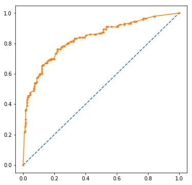

```python
import matplotlib.pyplot as plt
plt.figure(figsize=(6,6))
# calculate roc curve
fpr, tpr, thresholds = roc_curve(y_test, y_probs)
# plot no skill
plt.plot([0, 1], [0, 1], linestyle='--')
# plot the roc curve for the model
plt.plot(fpr, tpr, marker='.')
# show the plot
plt.show()
```

```python
clf_now.predict([[35, 50, 0, 1, 3], [18, 250, 1, 0, 2]]) # tuoi, gia ve, gioi tinh, tang lop
```

```
array([0, 1], dtype=int64)
```